# Company Default Data

### Outlier detection & Treatment

#### Creating outlier identification (Lower & Upper whiskers) function

[figure not shown]

```python
# Checking Outliers in dataset

col_names = list(Company.columns)
col_names.remove('Num')
fig, ax = plt.subplots(len(col_names), figsize=(8,100))

for i, col_val in enumerate(col_names):

    sns.boxplot(y=Company[col_val], ax=ax[i])
    ax[i].set_title('Box plot - {}'.format(col_val), fontsize=10)
    ax[i].set_xlabel(col_val, fontsize=8)

plt.show()
```

There are outliers in the dataset, lets use capping method to treat them

```python
def check_outlier(col):
    sorted(col)
    Q1,Q3=col.quantile([.25,.75])
    IQR=Q3-Q1
    lower_range= Q1-(1.5 * IQR)
    upper_range= Q3+(1.5 * IQR)
    return lower_range, upper_range
```

#### lets check outliers(Lower and Upper whiskers) in these variables

```python
check_outlier(Company['Networth_Next_Year'])
```

```
(-615.2, 1118.4)
```

```python
check_outlier(Company['Total_Income'])
```

```
(-2483.35, 4477.05)
```

```python
check_outlier(Company['PBT_as_perc_of_total_income'])
```

```
(-11.75, 20.89)
```

#### Capping the outliers

```python
def treat_outlier(x):
    # taking 5,25,75 percentile of column
    q5= np.percentile(x,5)
    q25=np.percentile(x,25)
    q75=np.percentile(x,75)
    dt=np.percentile(x,95)
    #calculationg IQR range
    IQR=q75-q25
    #Calculating minimum threshold
    lower_bound=q25-(1.5*IQR)
    upper_bound=q75+(1.5*IQR)
    #Calculating maximum threshold
    print(q5,q25,q75,dt,min,max)
    #Capping outliers
    return x.apply(lambda y: dt if y > upper_bound else y).apply(lambda y: q5 if y < lower_bound else y)
```

```python
for i in Company:
    Company[i]=treat_outlier(Company[i])
```

[output not shown]

[output cut: 21 more lines]

```
0.0 0.23 1.77 6.515999999999998 <built-in function min> <built-in function max>
0.0 0.03 0.21 1.25 <built-in function min> <built-in function max>
0.26400000000000007 3.11 25.39 186.47399999999976 <built-in function min> <built-in function max>
0.06800000000000012 3.96 15.32 39.57799999999996 <built-in function min> <built-in function max>
0.0 4.03 15.2 42.08599999999991 <built-in function min> <built-in function max>
3.074 10.21 87.5324658 157.76999999999992 <built-in function min> <built-in function max>
1.8520000000000003 5.99 27.97205637 70.31199999999998 <built-in function min> <built-in function max>
0.0 3.39 16.29 31.915999999999983 <built-in function min> <built-in function max>
103148.0 2212500.0 22284601.68 59535979.599999964 <built-in function min> <built-in function max>
-1348.444874 10.0 10.0 100.0 <built-in function min> <built-in function max>
-4.816 0.0 10.12 90.53599999999985 <built-in function min> <built-in function max>
-4.832 0.0 7.73 88.53799999999984 <built-in function min> <built-in function max>
15.2 97.6 1099.2 8835.079999999965 <built-in function min> <built-in function max>
-2.2279999999999998 13.99 64.07801191 64.07801191 <built-in function min> <built-in function max>
1.0 1.0 1.0 1.0 <built-in function min> <built-in function max>
```

```python
Company.shape
```

```
(2409, 76)
```

### Let us check significance of variables 'PBT_as_perc_of_total_income' in predicting Networth_Next_Year(default) before proceeding to model development

#### Checking Descriptive statistics of the variable 'PBT_as_perc_of_total_income'

```python
Company['PBT_as_perc_of_total_income'].describe()
```

```
count    2409.000000
mean        3.581635
std        10.147879
min       -21.140000
25%         0.490000
50%         3.280000
75%         8.650000
max        22.688000
Name: PBT_as_perc_of_total_income, dtype: float64
```

#### Checking Descriptive statistics of the variable 'PBT_as_perc_of_total_income' for non defaulters

```python
Company.loc[Company['default'] == 0,'PBT_as_perc_of_total_income'].describe()
```

```
count    2240.000000
mean        4.611910
std         9.236063
min       -21.140000
25%         0.920000
50%         3.690000
75%         9.182500
max        22.688000
Name: PBT_as_perc_of_total_income, dtype: float64
```

For companies whose *have not* defaulted, median 'Profit before tax (as % of income) is about 3.7'

#### Checking Descriptive statistics of the variable 'PBT_as_perc_of_total_income' for defaulters

```python
Company.loc[Company['default'] == 1,'PBT_as_perc_of_total_income'].describe()
```

```
count    169.000000
mean     -10.074083
std       11.722073
min      -21.140000
25%      -21.140000
50%      -10.320000
75%        0.000000
max       22.688000
Name: PBT_as_perc_of_total_income, dtype: float64
```

For companies whose *have* defaulted, median 'Profit before tax (as % of income) is about -10.3'

- In conclusion what it means is, typical good companies makes a profit of about 3.7 units per 100 units of income
- And a typical defaulted companies loses about 10.3 units per 100 units of income

# Model Building using Logistic Regression for 'Probability at default'

## The equation of the Logistic Regression by which we predict the corresponding probabilities and then go on predict a discrete target variable is

# y = $\frac{1}{1 - {e^{-z}}}$

### Note: z = $\beta_0$ +${\sum_{i=1}^{n}(\beta_i X_1)}$

#### Now, Importing statsmodels modules

```python
import statsmodels.formula.api as SM
```

#### Creating logistic regression equation & storing it in f_1

model = SM.logit(formula=’Dependent Variable ~ Σ𝐼𝑛𝑑𝑒𝑝𝑒𝑛𝑑𝑒𝑛𝑡 𝑉𝑎𝑟𝑖𝑎𝑏𝑙𝑒𝑠 (𝑘)’ data = ‘Data Frame containing the required values’).fit()

##### Splitting arrays or matrices into random train and test subsets. Model will be fitted on train set and predictions will be made on the test set

```python
X = Company.drop(['default','Networth_Next_Year','Num'], axis=1)
y = Company['default']

from sklearn.model_selection import train_test_split
X_train, X_test, y_train, y_test = train_test_split(X,y,test_size=0.33,random_state=42,stratify=Company['default'])

Company_train = pd.concat([X_train,y_train], axis=1)
Company_test = pd.concat([X_test,y_test], axis=1)

Company_train.to_csv('Company_train.csv',index=False)
Company_test.to_csv('Company_test.csv',index=False)
```

```python
Company_train.columns
```

```
Index(['Total_assets', 'Net_worth', 'Total_Income',
       'Total_Income_by_Total_assets', 'Change_in_stock',
       'Change_in_stock_by_Total_Income', 'Total_expenses',
       'Total_expenses_by_Total_Income', 'Profit_after_tax',
       'Profit_after_tax_by_Total_assets', 'PBDITA', 'PBDITA_by_Total_assets',
       'PBT', 'PBT_by_Total_assets', 'Cash_profit',
       'Cash_profit_by_Total_assets', 'PBDITA_as_perc_of_total_income',
       'PBT_as_perc_of_total_income', 'PAT_as_perc_of_total_income',
       'Cash_profit_as_perc_of_total_income', 'PAT_as_perc_of_net_worth',
       'Sales', 'Sales_by_Total_assets', 'Income_from_financial_services',
       'Income_from_financial_services_by_Total_Income', 'Other_income',
       'Other_income_by_Total_Income', 'Total_capital',
       'Total_capital_by_Total_Assets', 'Reserves_and_funds',
       'Reserves_and_funds_by_Total_Assets', 'Borrowings',
       'Borrowings_by_Total_Assets', 'Current_liabilities_and_provisions',
       'Current_liabilities_and_provisions_by_Total_assets',
       'Deferred_tax_liability', 'Deferred_tax_liability_by_Total_Assets',
       'Shareholders_funds', 'Shareholders_funds_by_Total_assets',
       'Cumulative_retained_profits',
       'Cumulative_retained_profits_by_Total_Income', 'Capital_employed',
       'Capital_employed_by_Total_assets', 'TOL_by_TNW',
       'Total_term_liabilities__by__tangible_net_worth',
       'Contingent_liabilities__by__Net_worth_perc', 'Contingent_liabilities',
       'Contingent_liabilities_by_Total_Assets', 'Net_fixed_assets',
       'Net_fixed_assets_by_Total_Assets', 'Investments',
       'Investments_by_Total_Income', 'Current_assets',
       'Current_assets_by_Total_Assets', 'Net_working_capital',
       'Net_working_capital_by_Total_Capital', 'Quick_ratio_times',
       'Current_ratio_times', 'Debt_to_equity_ratio_times',
       'Cash_to_current_liabilities_times',
       'Cash_to_average_cost_of_sales_per_day', 'Creditors_turnover',
       'Debtors_turnover', 'Finished_goods_turnover', 'WIP_turnover',
       'Raw_material_turnover', 'Shares_outstanding', 'Equity_face_value',
       'EPS', 'Adjusted_EPS', 'Total_liabilities', 'PE_on_BSE', 'Dev_model',
       'default'],
      dtype='object')
```

## Model 1

Before starting model building, lets look at the problem of multicollinearity. Multicollinearity occurs when two or more independent variables are highly correlated with one another in a regression model.

```python
# Import library for VIF
from statsmodels.stats.outliers_influence import variance_inflation_factor

def calc_vif(X):

    # Calculating VIF
    vif = pd.DataFrame()
    vif["variables"] = X.columns
    vif["VIF"] = [variance_inflation_factor(X.values, i) for i in range(X.shape[1])]

    return(vif)
```

```python
calc_vif(X_train).sort_values(by='VIF', ascending = True)
```

|  | variables | VIF |
| --- | --- | --- |
| 45 | Contingent_liabilities__by__Net_worth_perc | 1.262117 |
| 71 | PE_on_BSE | 1.371907 |
| 65 | Raw_material_turnover | 1.457993 |
| 50 | Investments | 1.613993 |
| 4 | Change_in_stock | 1.706929 |
| 62 | Debtors_turnover | 1.711831 |
| 61 | Creditors_turnover | 1.768949 |
| 5 | Change_in_stock_by_Total_Income | 1.863721 |
| 46 | Contingent_liabilities | 1.979391 |
| 25 | Other_income | 1.989548 |
| 55 | Net_working_capital_by_Total_Capital | 2.233915 |
| 63 | Finished_goods_turnover | 2.340059 |
| 51 | Investments_by_Total_Income | 2.356976 |
| 64 | WIP_turnover | 2.418147 |
| 54 | Net_working_capital | 2.453126 |
| 49 | Net_fixed_assets_by_Total_Assets | 2.524236 |
| 67 | Equity_face_value | 2.658062 |
| 32 | Borrowings_by_Total_Assets | 2.683636 |
| 60 | Cash_to_average_cost_of_sales_per_day | 2.722499 |
| 47 | Contingent_liabilities_by_Total_Assets | 2.833447 |
| 35 | Deferred_tax_liability | 2.836829 |
| 26 | Other_income_by_Total_Income | 2.937239 |
| 23 | Income_from_financial_services | 3.103908 |
| 40 | Cumulative_retained_profits_by_Total_Income | 3.124709 |
| 20 | PAT_as_perc_of_net_worth | 3.168076 |
| 24 | Income_from_financial_services_by_Total_Income | 3.349914 |
| 36 | Deferred_tax_liability_by_Total_Assets | 3.403342 |
| 53 | Current_assets_by_Total_Assets | 3.601563 |
| 59 | Cash_to_current_liabilities_times | 3.690171 |
| 48 | Net_fixed_assets | 4.133867 |
| ... | ... | ... |
| 33 | Current_liabilities_and_provisions | 5.922509 |
| 43 | TOL_by_TNW | 6.392183 |
| 22 | Sales_by_Total_assets | 6.879268 |
| 52 | Current_assets | 7.063778 |
| 30 | Reserves_and_funds_by_Total_Assets | 7.330419 |
| 38 | Shareholders_funds_by_Total_assets | 7.772884 |
| 29 | Reserves_and_funds | 8.569776 |
| 16 | PBDITA_as_perc_of_total_income | 8.770527 |
| 3 | Total_Income_by_Total_assets | 9.338925 |
| 58 | Debt_to_equity_ratio_times | 9.408160 |
| 19 | Cash_profit_as_perc_of_total_income | 13.826134 |
| 41 | Capital_employed | 17.126263 |
| 6 | Total_expenses | 18.125364 |
| 11 | PBDITA_by_Total_assets | 18.716639 |
| 14 | Cash_profit | 19.287246 |
| 21 | Sales | 20.697583 |
| 10 | PBDITA | 21.230536 |
| 15 | Cash_profit_by_Total_assets | 21.530913 |
| 8 | Profit_after_tax | 24.076989 |
| 12 | PBT | 25.865234 |
| 18 | PAT_as_perc_of_total_income | 30.186683 |
| 2 | Total_Income | 30.757437 |
| 37 | Shareholders_funds | 33.057718 |
| 9 | Profit_after_tax_by_Total_assets | 33.820119 |
| 1 | Net_worth | 34.278786 |
| 17 | PBT_as_perc_of_total_income | 34.280187 |
| 13 | PBT_by_Total_assets | 36.137749 |
| 72 | Dev_model | 587.879602 |
| 70 | Total_liabilities | inf |
| 0 | Total_assets | inf |

73 rows × 2 columns

Here, we see that the value of VIF is high for many variables. Here, we may drop variables with VIF more than 5 (very high correlation) & build our model

```python
f_1 = 'default ~ Adjusted_EPS + Cumulative_retained_profits + Total_expenses_by_Total_Income + Total_capital + Net_fixed_assets + Cash_to_current_liabilities_times + Current_assets_by_Total_Assets + Deferred_tax_liability_by_Total_Assets + Income_from_financial_services_by_Total_Income + PAT_as_perc_of_net_worth + Cumulative_retained_profits_by_Total_Income + Income_from_financial_services + Other_income_by_Total_Income + Deferred_tax_liability + Contingent_liabilities_by_Total_Assets + Cash_to_average_cost_of_sales_per_day + Borrowings_by_Total_Assets + Equity_face_value + Net_fixed_assets_by_Total_Assets + Net_working_capital + WIP_turnover + Investments_by_Total_Income + Finished_goods_turnover + Net_working_capital_by_Total_Capital + Other_income + Contingent_liabilities + Change_in_stock_by_Total_Income + Creditors_turnover + Debtors_turnover + Change_in_stock + Investments + Raw_material_turnover + PE_on_BSE + Contingent_liabilities__by__Net_worth_perc'
```

#### Fitting the logistic regression model

```python
model_1 = SM.logit(formula = f_1, data=Company).fit()
```

```
Optimization terminated successfully.
         Current function value: 0.135954
         Iterations 10
```

#### Studying whether this equation is significant or not

```python
model_1.summary()
```

Logit Regression Results

| Dep. Variable: | default | No. Observations: | 2409 |
| --- | --- | --- | --- |
| Model: | Logit | Df Residuals: | 2374 |
| Method: | MLE | Df Model: | 34 |
| Date: | Mon, 31 Aug 2020 | Pseudo R-squ.: | 0.4648 |
| Time: | 12:23:34 | Log-Likelihood: | -327.51 |
| converged: | True | LL-Null: | -611.97 |
| Covariance Type: | nonrobust | LLR p-value: | 2.689e-98 |

|  | coef | std err | z | P>\|z\| | [0.025 | 0.975] |
| --- | --- | --- | --- | --- | --- | --- |
| Intercept | -3.9379 | 1.090 | -3.613 | 0.000 | -6.074 | -1.802 |
| Adjusted_EPS | -0.0226 | 0.013 | -1.684 | 0.092 | -0.049 | 0.004 |
| Cumulative_retained_profits | 0.0004 | 0.000 | 1.714 | 0.087 | -6.16e-05 | 0.001 |
| Total_expenses_by_Total_Income | -0.1733 | 0.922 | -0.188 | 0.851 | -1.980 | 1.633 |
| Total_capital | -0.0027 | 0.001 | -2.824 | 0.005 | -0.005 | -0.001 |
| Net_fixed_assets | 0.0003 | 0.000 | 1.882 | 0.060 | -1.26e-05 | 0.001 |
| Cash_to_current_liabilities_times | -0.0157 | 0.301 | -0.052 | 0.958 | -0.605 | 0.574 |
| Current_assets_by_Total_Assets | -0.4262 | 0.545 | -0.782 | 0.434 | -1.494 | 0.642 |
| Deferred_tax_liability_by_Total_Assets | -0.0021 | 0.033 | -0.064 | 0.949 | -0.067 | 0.063 |
| Income_from_financial_services_by_Total_Income | 0.1022 | 0.087 | 1.168 | 0.243 | -0.069 | 0.274 |
| PAT_as_perc_of_net_worth | -0.0927 | 0.010 | -9.530 | 0.000 | -0.112 | -0.074 |
| Cumulative_retained_profits_by_Total_Income | -2.0638 | 0.368 | -5.614 | 0.000 | -2.784 | -1.343 |
| Income_from_financial_services | -0.0018 | 0.005 | -0.404 | 0.686 | -0.011 | 0.007 |
| Other_income_by_Total_Income | -0.0981 | 0.114 | -0.858 | 0.391 | -0.322 | 0.126 |
| Deferred_tax_liability | 0.0007 | 0.002 | 0.427 | 0.669 | -0.002 | 0.004 |
| Contingent_liabilities_by_Total_Assets | 0.0217 | 0.008 | 2.819 | 0.005 | 0.007 | 0.037 |
| Cash_to_average_cost_of_sales_per_day | 0.0017 | 0.002 | 0.916 | 0.360 | -0.002 | 0.005 |
| Borrowings_by_Total_Assets | 0.0111 | 0.022 | 0.514 | 0.607 | -0.031 | 0.053 |
| Equity_face_value | -1.314e-05 | 0.000 | -0.070 | 0.944 | -0.000 | 0.000 |
| Net_fixed_assets_by_Total_Assets | 1.0835 | 0.558 | 1.940 | 0.052 | -0.011 | 2.178 |
| Net_working_capital | -0.0012 | 0.001 | -1.339 | 0.181 | -0.003 | 0.001 |
| WIP_turnover | -0.0056 | 0.010 | -0.534 | 0.594 | -0.026 | 0.015 |
| Investments_by_Total_Income | -0.0285 | 0.009 | -3.040 | 0.002 | -0.047 | -0.010 |
| Finished_goods_turnover | 0.0020 | 0.004 | 0.460 | 0.645 | -0.006 | 0.010 |
| Net_working_capital_by_Total_Capital | 0.0217 | 0.043 | 0.499 | 0.618 | -0.064 | 0.107 |
| Other_income | 0.0010 | 0.008 | 0.119 | 0.906 | -0.015 | 0.017 |
| Contingent_liabilities | -0.0008 | 0.000 | -2.273 | 0.023 | -0.002 | -0.000 |
| Change_in_stock_by_Total_Income | 0.1094 | 0.247 | 0.442 | 0.658 | -0.376 | 0.595 |
| Creditors_turnover | -0.0151 | 0.016 | -0.954 | 0.340 | -0.046 | 0.016 |
| Debtors_turnover | 0.0129 | 0.012 | 1.086 | 0.277 | -0.010 | 0.036 |
| Change_in_stock | 0.0015 | 0.004 | 0.351 | 0.726 | -0.007 | 0.010 |
| Investments | 0.0012 | 0.000 | 2.936 | 0.003 | 0.000 | 0.002 |
| Raw_material_turnover | 0.0095 | 0.014 | 0.659 | 0.510 | -0.019 | 0.038 |
| PE_on_BSE | 0.0086 | 0.004 | 2.303 | 0.021 | 0.001 | 0.016 |
| Contingent_liabilities__by__Net_worth_perc | 0.0099 | 0.002 | 4.876 | 0.000 | 0.006 | 0.014 |

Let us look at the adjusted pseudo R-square value

```python
print('The adjusted pseudo R-square value is',1 - ((model_1.llf - model_1.df_model)/model_1.llnull))
```

```
The adjusted pseudo R-square value is 0.4092656890548343
```

Adjusted pseudo R-square seems to be lower than Pseudo R-square value which means there are insignificant variables present in the model. Lets try & remove variables whose p value is greater than 0.05 & rebuild our model

## Model 2

```python
f_2 = 'default ~ Total_capital + Net_fixed_assets + PAT_as_perc_of_net_worth + Cumulative_retained_profits_by_Total_Income + Contingent_liabilities_by_Total_Assets + Investments_by_Total_Income + Contingent_liabilities + Investments + PE_on_BSE + Contingent_liabilities__by__Net_worth_perc'
```

```python
model_2 = SM.logit(formula = f_2, data=Company_train).fit()
```

```
Optimization terminated successfully.
         Current function value: 0.139671
         Iterations 9
```

```python
model_2.summary()
```

Logit Regression Results

| Dep. Variable: | default | No. Observations: | 1614 |
| --- | --- | --- | --- |
| Model: | Logit | Df Residuals: | 1603 |
| Method: | MLE | Df Model: | 10 |
| Date: | Mon, 31 Aug 2020 | Pseudo R-squ.: | 0.4494 |
| Time: | 12:23:40 | Log-Likelihood: | -225.43 |
| converged: | True | LL-Null: | -409.42 |
| Covariance Type: | nonrobust | LLR p-value: | 6.028e-73 |

|  | coef | std err | z | P>\|z\| | [0.025 | 0.975] |
| --- | --- | --- | --- | --- | --- | --- |
| Intercept | -3.8271 | 0.364 | -10.504 | 0.000 | -4.541 | -3.113 |
| Total_capital | -0.0037 | 0.001 | -3.311 | 0.001 | -0.006 | -0.001 |
| Net_fixed_assets | 0.0007 | 0.000 | 4.222 | 0.000 | 0.000 | 0.001 |
| PAT_as_perc_of_net_worth | -0.0986 | 0.010 | -9.921 | 0.000 | -0.118 | -0.079 |
| Cumulative_retained_profits_by_Total_Income | -2.3753 | 0.409 | -5.807 | 0.000 | -3.177 | -1.574 |
| Contingent_liabilities_by_Total_Assets | 0.0292 | 0.009 | 3.255 | 0.001 | 0.012 | 0.047 |
| Investments_by_Total_Income | -0.0206 | 0.009 | -2.348 | 0.019 | -0.038 | -0.003 |
| Contingent_liabilities | -0.0011 | 0.000 | -2.374 | 0.018 | -0.002 | -0.000 |
| Investments | 0.0011 | 0.000 | 2.571 | 0.010 | 0.000 | 0.002 |
| PE_on_BSE | 0.0128 | 0.004 | 2.893 | 0.004 | 0.004 | 0.021 |
| Contingent_liabilities__by__Net_worth_perc | 0.0081 | 0.002 | 3.404 | 0.001 | 0.003 | 0.013 |

We can see that all variables are significant & may be useful to discriminate cases of deault

Let us also check the multicollinearity of the model using Variance Inflation Factor (VIF) for the predictor variables

```python
calc_vif(X_train[['Total_capital','Net_fixed_assets', 'PAT_as_perc_of_net_worth' , 'Cumulative_retained_profits_by_Total_Income' , 'Contingent_liabilities_by_Total_Assets' , 'Investments_by_Total_Income' , 'Contingent_liabilities' , 'Investments' , 'PE_on_BSE' , 'Contingent_liabilities__by__Net_worth_perc']]).sort_values(by='VIF', ascending = True)
```

|  | variables | VIF |
| --- | --- | --- |
| 3 | Cumulative_retained_profits_by_Total_Income | 1.353936 |
| 9 | Contingent_liabilities__by__Net_worth_perc | 1.406154 |
| 2 | PAT_as_perc_of_net_worth | 1.479623 |
| 5 | Investments_by_Total_Income | 1.975775 |
| 1 | Net_fixed_assets | 2.236608 |
| 0 | Total_capital | 2.261477 |
| 8 | PE_on_BSE | 2.447948 |
| 7 | Investments | 2.563008 |
| 4 | Contingent_liabilities_by_Total_Assets | 2.609765 |
| 6 | Contingent_liabilities | 3.285351 |

We can see that multicollinearity still exists but lets not drop them as VIFs are not very high

```python
print('The adjusted pseudo R-square value is',1 - ((model_2.llf - model_2.df_model)/model_2.llnull))
```

```
The adjusted pseudo R-square value is 0.4249760562990271
```

We see that adjusted R sq is now close to Rsq, thus suggesting lesser insignificant variables in the model

We also notice that current model has no insignificant variables and can be used for prediction purposes.

Lets test the prediction of this model on train and test dataset

## Prediction on the Data

Let us first check the distribution plot of the logit function values

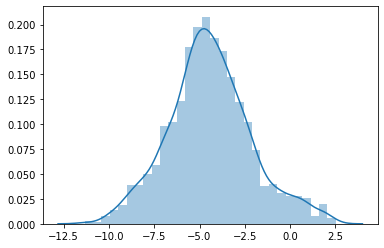

```python
sns.distplot(model_2.fittedvalues);
```

Now, let us see the predicted probability values:

#### Prediction on Train set

```python
y_predict_train = model_2.predict(X_train)
y_predict_train
```

```
1195    0.000238
630     0.079001
1978    0.005952
2312    0.000817
1000    0.012295
464     0.282067
198     0.034514
711     0.280323
1949    0.001276
2206    0.001816
1986    0.000249
265     0.146941
52      0.782141
1570    0.174541
1701    0.007760
```

[output cut: 47 more lines]

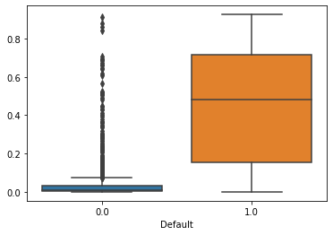

```python
sns.boxplot(x=Company['default'],y=y_predict_train)
plt.xlabel('Default');
```

From the above boxplot, we need to decide on one such value of a cut-off which will give us the most reasonable descriptive power of the model. Let us take a cut-off of 0.07 and check.

Let us now see the predicted classes

```python
y_class_pred=[]
for i in range(0,len(y_predict_train)):
    if np.array(y_predict_train)[i]>0.07:
        a=1
    else:
        a=0
    y_class_pred.append(a)
```

#### Checking the accuracy of the model using confusion matrix for training set

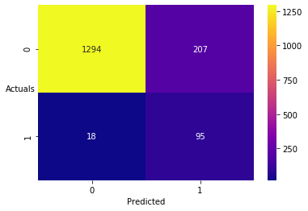

```python
#print(metrics.confusion_matrix(y_test, y_predict))
sns.heatmap((metrics.confusion_matrix(y_train,y_class_pred)),annot=True,fmt='.5g'
            ,cmap='plasma');
plt.xlabel('Predicted');
plt.ylabel('Actuals',rotation=0);
```

```python
tn, fp, fn, tp = metrics.confusion_matrix(y_train,y_class_pred).ravel()
print('True Negative:',tn,'\n''False Positives:' ,fp,'\n''False Negatives:', fn,'\n''True Positives:', tp)
```

```
True Negative: 1294
False Positives: 207
False Negatives: 18
True Positives: 95
```

```python
print(metrics.classification_report(y_train,y_class_pred,digits=3))
```

```
              precision    recall  f1-score   support

         0.0      0.986     0.862     0.920      1501
         1.0      0.315     0.841     0.458       113

    accuracy                          0.861      1614
   macro avg      0.650     0.851     0.689      1614
weighted avg      0.939     0.861     0.888      1614
```

- As observed above, accuracy of the model i.e. %overall correct predictions is 86%
- Sensitivity of the model is 84% i.e. 84% of those defaulted were correctly identified as defaulters by the model

#### Prediction on Test set

```python
y_predict_test = model_2.predict(X_test)
y_predict_test
```

```
1238    0.264364
1446    0.009470
840     0.007608
166     0.054838
658     0.007321
1691    0.018224
499     0.032348
366     0.001656
1129    0.017894
1517    0.009549
868     0.033910
927     0.039776
1451    0.008103
2245    0.000346
1651    0.016640
```

[output cut: 47 more lines]

```python
y_class_pred=[]
for i in range(0,len(y_predict_test)):
    if np.array(y_predict_test)[i]>0.07:
        a=1
    else:
        a=0
    y_class_pred.append(a)
```

#### Checking the accuracy of the model using confusion matrix for test set

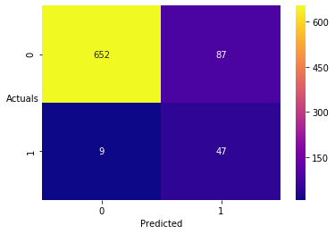

```python
#print(metrics.confusion_matrix(y_test, y_predict))
sns.heatmap((metrics.confusion_matrix(y_test,y_class_pred)),annot=True,fmt='.5g'
            ,cmap='plasma');
plt.xlabel('Predicted');
plt.ylabel('Actuals',rotation=0);
```

```python
tn, fp, fn, tp = metrics.confusion_matrix(y_test,y_class_pred).ravel()
print('True Negative:',tn,'\n''False Positives:' ,fp,'\n''False Negatives:', fn,'\n''True Positives:', tp)
```

```
True Negative: 652
False Positives: 87
False Negatives: 9
True Positives: 47
```

Let us now go ahead and print the classification report to check the various other parameters

```python
print(metrics.classification_report(y_test,y_class_pred,digits=3))
```

```
              precision    recall  f1-score   support

         0.0      0.986     0.882     0.931       739
         1.0      0.351     0.839     0.495        56

    accuracy                          0.879       795
   macro avg      0.669     0.861     0.713       795
weighted avg      0.942     0.879     0.901       795
```

- As observed above, accuracy of the model i.e. %overall correct predictions is 88%
- Sensitivity of the model is 84% i.e. 84% of those defaulted were correctly identified as defaulters by the model

### Let us take a cut-off of 0.08 and check if our predictions have improved

```python
y_class_pred=[]
for i in range(0,len(y_predict_train)):
    if np.array(y_predict_train)[i]>0.08:
        a=1
    else:
        a=0
    y_class_pred.append(a)
```

#### Checking the accuracy of the model using confusion matrix for training set

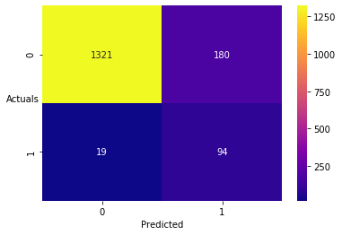

```python
#print(metrics.confusion_matrix(y_test, y_predict))
sns.heatmap((metrics.confusion_matrix(y_train,y_class_pred)),annot=True,fmt='.5g'
            ,cmap='plasma');
plt.xlabel('Predicted');
plt.ylabel('Actuals',rotation=0);
```

```python
tn, fp, fn, tp = metrics.confusion_matrix(y_train,y_class_pred).ravel()
print('True Negative:',tn,'\n''False Positives:' ,fp,'\n''False Negatives:', fn,'\n''True Positives:', tp)
```

```
True Negative: 1321
False Positives: 180
False Negatives: 19
True Positives: 94
```

```python
print(metrics.classification_report(y_train,y_class_pred,digits=3))
```

```
              precision    recall  f1-score   support

         0.0      0.986     0.880     0.930      1501
         1.0      0.343     0.832     0.486       113

    accuracy                          0.877      1614
   macro avg      0.664     0.856     0.708      1614
weighted avg      0.941     0.877     0.899      1614
```

Accuracy of the model i.e. %overall correct predictions has increased from 86% to 88% but sensitivity of the model has dropped slightly from 84% to 83%

#### Prediction on Test set

```python
y_predict_test = model_2.predict(X_test)
y_predict_test
```

```
1238    0.264364
1446    0.009470
840     0.007608
166     0.054838
658     0.007321
1691    0.018224
499     0.032348
366     0.001656
1129    0.017894
1517    0.009549
868     0.033910
927     0.039776
1451    0.008103
2245    0.000346
1651    0.016640
```

[output cut: 47 more lines]

```python
y_class_pred=[]
for i in range(0,len(y_predict_test)):
    if np.array(y_predict_test)[i]>0.08:
        a=1
    else:
        a=0
    y_class_pred.append(a)
```

#### Checking the accuracy of the model using confusion matrix for test set

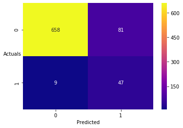

```python
#print(metrics.confusion_matrix(y_test, y_predict))
sns.heatmap((metrics.confusion_matrix(y_test,y_class_pred)),annot=True,fmt='.5g'
            ,cmap='plasma');
plt.xlabel('Predicted');
plt.ylabel('Actuals',rotation=0);
```

```python
tn, fp, fn, tp = metrics.confusion_matrix(y_test,y_class_pred).ravel()
print('True Negative:',tn,'\n''False Positives:' ,fp,'\n''False Negatives:', fn,'\n''True Positives:', tp)
```

```
True Negative: 658
False Positives: 81
False Negatives: 9
True Positives: 47
```

Let us now go ahead and print the classification report to check the various other parameters

```python
print(metrics.classification_report(y_test,y_class_pred,digits=3))
```

```
              precision    recall  f1-score   support

         0.0      0.987     0.890     0.936       739
         1.0      0.367     0.839     0.511        56

    accuracy                          0.887       795
   macro avg      0.677     0.865     0.723       795
weighted avg      0.943     0.887     0.906       795
```

Accuracy of the model i.e. %overall correct predictions is 89% & sensitivity of the model stands at 84%